# Stroop analysis

Gary Lupyan

2022-10-13

# 1 Setup/Load libraries

```r
library(tidyverse)
library(ggplot2)
library(ggbeeswarm)
library(lme4)
theme_set(theme_bw(base_size = 12))
```

# 2 Load data

```r
dat <- read.csv("../raw_data/stroopData.csv") %>%
    mutate(RT = ifelse(RT<300,NA,RT),
                 RT_correct = ifelse(is_correct==0,NA,RT))
dat %>% summary
```

```
##    trial_num                       subj_code   prop_incongruent resp_type
##  Min.   :  1.00   stroop_andreagraystein:100   Min.   :0.2500   key:1300
##  1st Qu.: 25.75   stroop_drewbeatty     :100   1st Qu.:0.2500
##  Median : 50.50   stroop_ezgimelisa     :100   Median :0.5000
##  Mean   : 50.50   stroop_jacobike       :100   Mean   :0.4423
##  3rd Qu.: 75.25   stroop_leanthony2     :100   3rd Qu.:0.5000
##  Max.   :100.00   stroop_lmodahl        :100   Max.   :0.7500
##                   (Other)               :700
##      word        color           trial_type       orientation    resp
##  blue  :263   blue  :265   congruent  :725   upright    :650   b   :263
##  green :260   green :258   incongruent:575   upside_down:650   g   :255
##  orange:267   orange:277                                       o   :283
##  red   :249   red   :248                                       r   :253
##  yellow:261   yellow:252                                       y   :243
##                                                                NA's:  3
##
##    is_correct         RT           RT_correct
##  Min.   :0.00   Min.   : 336.0   Min.   : 336.0
##  1st Qu.:1.00   1st Qu.: 582.0   1st Qu.: 582.0
##  Median :1.00   Median : 703.0   Median : 703.0
##  Mean   :0.95   Mean   : 748.5   Mean   : 746.9
##  3rd Qu.:1.00   3rd Qu.: 848.2   3rd Qu.: 845.0
##  Max.   :1.00   Max.   :1893.0   Max.   :1879.0
##                 NA's   :4        NA's   :65
```

# 3 Example of pivoting from long to wide

Long/Tidy format – this is the format we’ll be working with most of the time. One row per observation. Each column repersesents a specific variable.

```r
dat %>%
    group_by(subj_code,orientation,trial_type) %>%
    summarize(RT_correct = mean(RT_correct,na.rm=TRUE)) %>% head
```

```
## # A tibble: 6 × 4
## # Groups:   subj_code, orientation [3]
##   subj_code              orientation trial_type  RT_correct
##   <fct>                  <fct>       <fct>            <dbl>
## 1 stroop_andreagraystein upright     congruent         652.
## 2 stroop_andreagraystein upright     incongruent       826.
## 3 stroop_andreagraystein upside_down congruent         654.
## 4 stroop_andreagraystein upside_down incongruent       857
## 5 stroop_drewbeatty      upright     congruent         765.
## 6 stroop_drewbeatty      upright     incongruent      1101.
```

Now let’s pivot to wide which allows us to easily compute, e.g., by-subject differences for a condition, but loses the paradigm of one-column=one variable (notice that now RTs are split across multiple columns).

```r
dat %>%
    group_by(subj_code,trial_type) %>%
    summarize(RT_correct = mean(RT_correct,na.rm=TRUE)) %>% pivot_wider(names_from=c(trial_type),values_from=RT_correct) %>%
    mutate(congruence_effect = incongruent - congruent) %>% head
```

```
## # A tibble: 6 × 4
## # Groups:   subj_code [6]
##   subj_code              congruent incongruent congruence_effect
##   <fct>                      <dbl>       <dbl>             <dbl>
## 1 stroop_andreagraystein      653.        844               191.
## 2 stroop_drewbeatty           764.       1098.              334.
## 3 stroop_ezgimelisa           607.        874.              267.
## 4 stroop_jacobike             671.       1018.              347.
## 5 stroop_leanthony2           654.        760.              107.
## 6 stroop_lmodahl              523.        674.              152.
```

# 4 Graphing

A basic interaction plot. Notice that we’re first averaging the data and then passing the averages to ggplot.

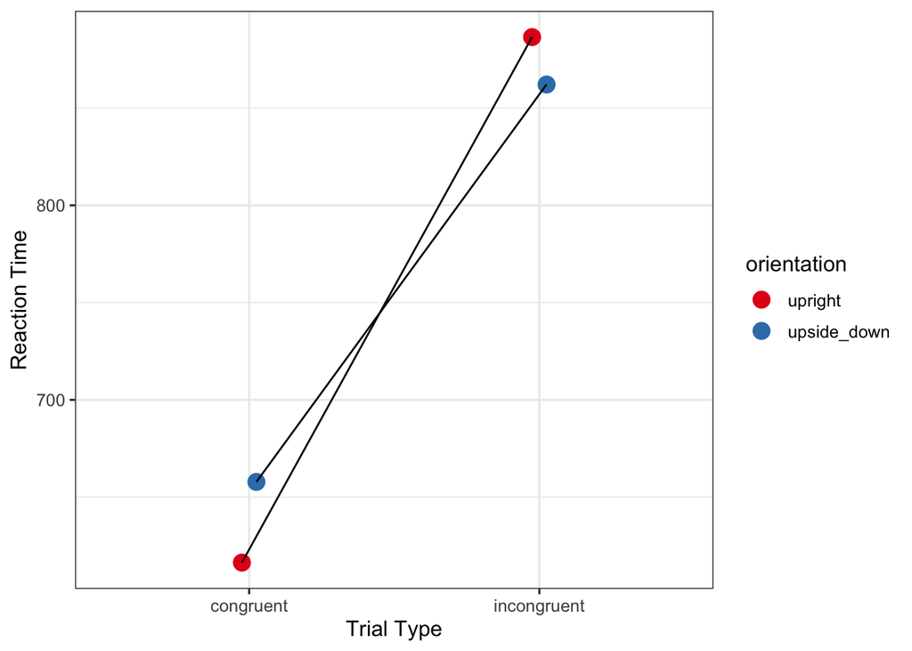

```r
dat %>%
    filter(prop_incongruent<=.5) %>%
    group_by(orientation,trial_type) %>% summarize(RT=mean(RT_correct,na.rm=TRUE)) %>%
    ggplot(aes(y=RT,x=trial_type,group=trial_type:orientation))+
    geom_point(aes(color=orientation),position = position_dodge(width = .1),size=4)+
  geom_line(aes(group=orientation),position = position_dodge(width = .1))+
    ylab("Reaction Time") +
  xlab("Trial Type")+
    scale_color_brewer(palette = "Set1")
```

Here’s a bar-chart version of the above graph. To my eye, the two main effects and their interaction is much harder to interpret, but your mileage may vary!

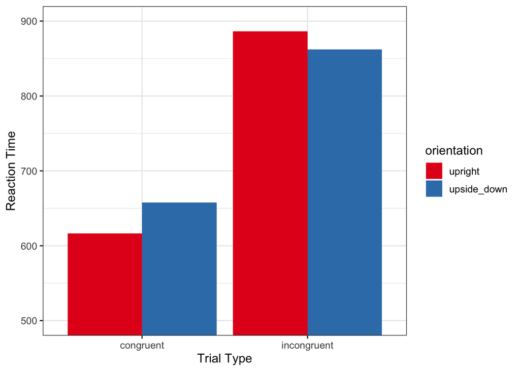

```r
dat %>%
    filter(prop_incongruent<=.5) %>%
    group_by(orientation,trial_type) %>% summarize(RT=mean(RT_correct,na.rm=TRUE)) %>%
    ggplot(aes(y=RT,x=trial_type,group=trial_type:orientation))+
    geom_bar(aes(fill=orientation),position = position_dodge(width = .9), stat="identity")+
    ylab("Reaction Time") +
  xlab("Trial Type") +
    coord_cartesian(ylim = c(500, 900))+
  scale_fill_brewer(palette = "Set1")
```

An example of faceting by `prop_incongruent` to see how the orientation:trial_type interaction differs in the two .25 and .50 conditions

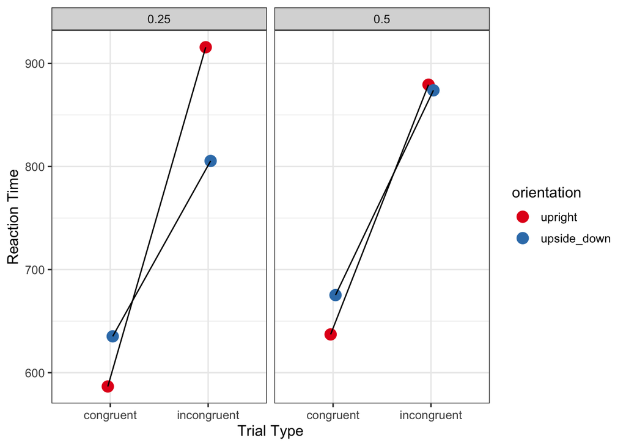

```r
dat %>%
    filter(prop_incongruent<=.5 & is_correct==1) %>%
    group_by(prop_incongruent,orientation,trial_type) %>% summarize(RT=mean(RT)) %>%
    ggplot(aes(y=RT,x=trial_type,group=trial_type:orientation))+
    geom_point(aes(color=orientation),position = position_dodge(width = .1),size=4)+
  geom_line(aes(group=orientation),position = position_dodge(width = .1))+
    ylab("Reaction Time") +
  xlab("Trial Type") +
  scale_color_brewer(palette = "Set1")+
    facet_wrap(~prop_incongruent)
```

Let’s combine a few graphing types to show RT distributions and individual RT means in each condition

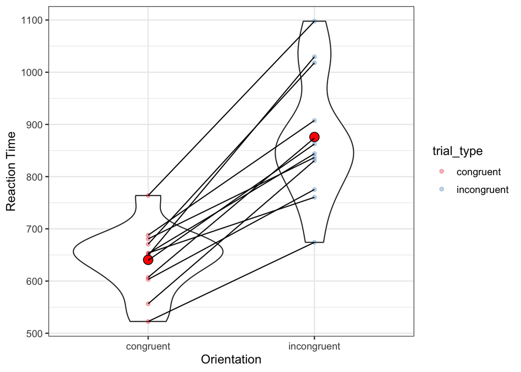

```r
dat %>%
    filter(prop_incongruent<=.5) %>%
    group_by(subj_code,trial_type) %>% summarize(RT=mean(RT_correct,na.rm=TRUE)) %>%
    ggplot(aes(y=RT,x=trial_type))+
  geom_violin() +
  ggbeeswarm::geom_beeswarm(aes(color=trial_type),alpha=.3,cex=.2,priority="density")+
  ylab("Reaction Time") +
  xlab("Orientation") +
    stat_summary(geom = "point", fun = mean, position = position_dodge(width = .1),shape=21, size=4, fill="red") +
    geom_line(aes(group=subj_code))+
  scale_color_brewer(palette = "Set1")
```

Same idea, but plotting accuracy instead

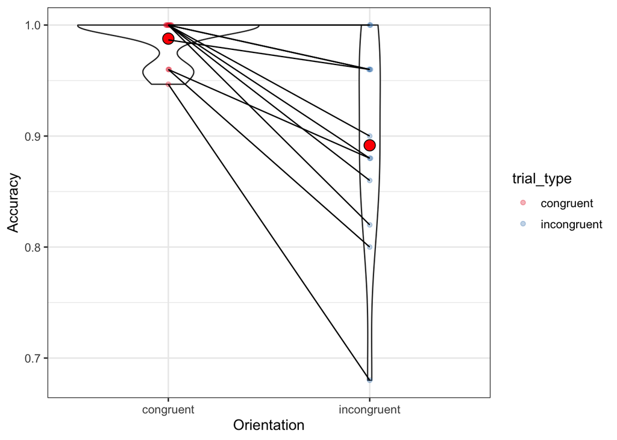

```r
dat %>%
    filter(prop_incongruent<=.5) %>%
    group_by(subj_code,trial_type) %>% summarize(is_correct=mean(is_correct)) %>%
    ggplot(aes(y=is_correct,x=trial_type))+
  geom_violin() +
  geom_beeswarm(aes(color=trial_type),alpha=.3,cex=.2,priority="density")+
  ylab("Accuracy") +
  xlab("Orientation") +
    stat_summary(geom = "point", fun = mean, position = position_dodge(width = .1),shape=21, size=4, fill="red") +
    geom_line(aes(group=subj_code))+
    scale_color_brewer(palette = "Set1")
```

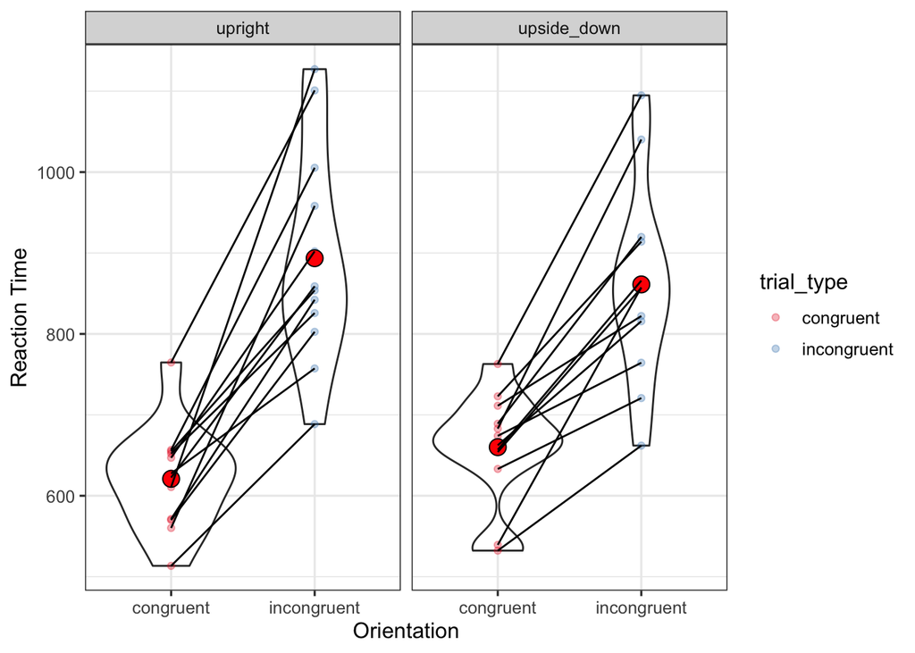

```r
dat %>%
    filter(prop_incongruent<=.5 & is_correct==1) %>%
    group_by(subj_code,orientation,trial_type) %>% summarize(RT=mean(RT)) %>%
    ggplot(aes(y=RT,x=trial_type))+
  geom_violin() +
  geom_beeswarm(aes(color=trial_type),alpha=.3,cex=.2,priority="density")+
  ylab("Reaction Time") +
  xlab("Orientation") +
    stat_summary(geom = "point", fun = mean, position = position_dodge(width = .1),shape=21, size=4, fill="red") +
    geom_line(aes(group=subj_code))+
    facet_grid(~ orientation)+
    scale_color_brewer(palette = "Set1")
```

# 5 Models

Here’s the stats model for those who’re curious (not modeling item effects here because we’re uninterested in generalizing to other ones, but one could of course include those and also see if certain color conflicts are especially confusing etc.)

Set contrasts to sum-coding (essentially centering the factors) so that the main effects are interpreted correctly in the presence of interactions

```r
contrasts(dat$trial_type) = contr.sum(2)
contrasts(dat$orientation) = contr.sum(2)
```

Linear mixed effects model

```r
dat %>% filter(prop_incongruent<=.5) %>%
    lmer(RT_correct~scale(prop_incongruent)*trial_type*orientation+(orientation+trial_type|subj_code),data=.) %>% summary
```

```
## Linear mixed model fit by REML ['lmerMod']
## Formula: RT_correct ~ scale(prop_incongruent) * trial_type * orientation +
##     (orientation + trial_type | subj_code)
##    Data: .
##
## REML criterion at convergence: 14941.3
##
## Scaled residuals:
##     Min      1Q  Median      3Q     Max
## -3.1181 -0.5349 -0.1097  0.4008  7.3387
##
## Random effects:
##  Groups    Name         Variance Std.Dev. Corr
##  subj_code (Intercept)   7380.51  85.910
##            orientation1     7.36   2.713   0.17
##            trial_type1   1433.58  37.863  -0.86 -0.65
##  Residual               28386.85 168.484
## Number of obs: 1142, groups:  subj_code, 12
##
## Fixed effects:
##                                                  Estimate Std. Error t value
## (Intercept)                                       757.953     25.376  29.869
## scale(prop_incongruent)                            11.754     25.466   0.462
## trial_type1                                      -116.961     12.179  -9.603
## orientation1                                       -2.280      5.440  -0.419
## scale(prop_incongruent):trial_type1                 9.384     12.350   0.760
## scale(prop_incongruent):orientation1               -6.867      5.806  -1.183
## trial_type1:orientation1                          -17.600      5.388  -3.266
## scale(prop_incongruent):trial_type1:orientation1    9.091      5.757   1.579
##
## Correlation of Fixed Effects:
##             (Intr) scl(_) trl_t1 orntt1 sc(_):_1 s(_):1 tr_1:1
## scl(prp_nc) -0.009
## trial_type1 -0.780  0.030
## orientatin1  0.022  0.004 -0.088
## scl(pr_):_1  0.030 -0.788 -0.038 -0.015
## scl(prp_):1  0.004  0.018 -0.015 -0.183 -0.071
## trl_typ1:r1 -0.002 -0.008 -0.003 -0.261  0.008    0.301
## scl(_):_1:1 -0.007  0.003  0.008  0.300 -0.008   -0.428 -0.186
## optimizer (nloptwrap) convergence code: 0 (OK)
## boundary (singular) fit: see help('isSingular')
```